# Linear models with factors II

Read the chapter 14-16

Linear models with only categorical predictors (or factors) have traditionally been called analysis of variance (ANOVA) problems. The idea is to partition the overall variance in the response due to each of the factors and the error.

# 1 One factor models

## 1.1 The model

Suppose we have a factor $\alpha$ occurring at $i = 1, \ldots , I$ levels, with $j = 1, \ldots, J_i$ observations per level. We use the model:

$$y_{ij} = \mu + \alpha_i + \epsilon_{ij}$$
The parameters are not identifiable. For example, we could add some constant to $\mu$ and subtract the same constant from each $\alpha_i$ and the fit would be unchanged. Some restriction is necessary. The identifiability can be guaranteed by some restriction as introduced in the privious chapter (See “Alternative codings of qualitative predictors”.)

Once that is done, the parameters (effects) can be estimated in the usual way along with standard errors. No matter which valid constraint and coding choice is made, the fitted values and residuals will be the same.

Once the effects are estimated, the natural first step is to test for differences in the levels of the factor.

$$H_0 : \alpha_1=\cdots=\alpha_I=0~~vs~~~H_1 : \mbox{not } H_0$$
(An explicit statement of the null and alternative hypotheses would depend on the coding used.)

Let $X$ be the design matrix under the above model, recall that the matrix formulae in the linear model.

$$SST = y^\top (I-J)y,~RSS = y^\top (I-H) y,~SSR = y^\top (H-J) y$$

where $J = {\bf{1}\bf{1}^\top},~{\bf{1}} = (1,\ldots,1)^\top$ and $H=X(X^\top X)^{-1} X^\top$.

Note that in one factor models.

$$\begin{eqnarray}
SST & = & \sum_{i=1}^I\sum_{j=1}^{J_i} ( y_{ij} - \bar{y}_{\cdot\cdot})^2 \\
RSS & = & \sum_{i=1}^I\sum_{j=1}^{J_i} ( y_{ij} - \bar{y}_{i\cdot})^2 \\
SSR & = & \sum_{i=1}^I J_i (\bar{y}_{i\cdot} - \bar{y}_{\cdot\cdot})^2 \\
\end{eqnarray}$$

In this particular model, $SSR$ is often expressed as $SS_{tr}$, sum of squares for treatment effects.

To do inference, we generally assume that $\epsilon_{ij} \sim^{iid} N(0,\sigma^2)$.

## 1.2 An Example

```r
library(faraway)
data(coagulation, package="faraway")
coagulation
```

```
##    coag diet
## 1    62    A
## 2    60    A
## 3    63    A
## 4    59    A
## 5    63    B
## 6    67    B
## 7    71    B
## 8    64    B
## 9    65    B
## 10   66    B
## 11   68    C
## 12   66    C
## 13   71    C
## 14   67    C
## 15   68    C
## 16   68    C
## 17   56    D
## 18   62    D
## 19   60    D
## 20   61    D
## 21   63    D
## 22   64    D
## 23   63    D
## 24   59    D
```

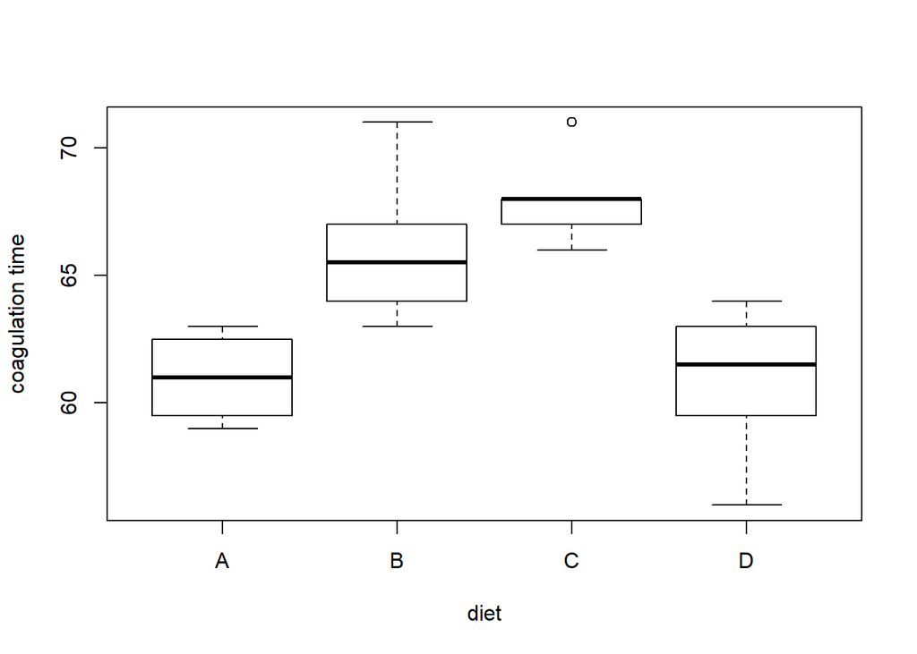

```r
plot(coag ~ diet, coagulation,ylab="coagulation time")
```

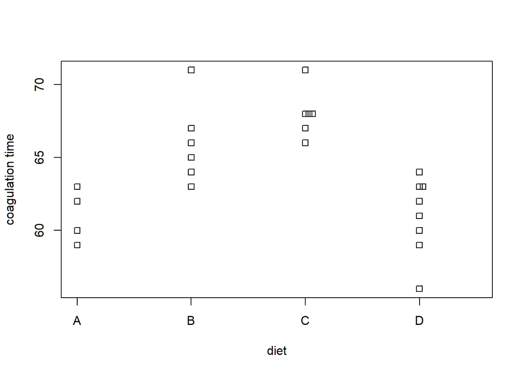

```r
stripchart(coag ~ diet, coagulation, vertical=TRUE, method="stack",xlab="diet",ylab="coagulation time")
```

What can we see?

```r
lmod <- lm(coag ~ diet, coagulation)
sumary(lmod)     # Estimates for group effects and their individual significance
```

```
##               Estimate Std. Error t value  Pr(>|t|)
## (Intercept) 6.1000e+01 1.1832e+00 51.5544 < 2.2e-16
## dietB       5.0000e+00 1.5275e+00  3.2733 0.0038025
## dietC       7.0000e+00 1.5275e+00  4.5826 0.0001805
## dietD       2.9914e-15 1.4491e+00  0.0000 1.0000000
##
## n = 24, p = 4, Residual SE = 2.36643, R-Squared = 0.67
```

```r
round(coef(lmod),1)
```

```
## (Intercept)       dietB       dietC       dietD
##          61           5           7           0
```

```r
model.matrix(lmod)
```

```
##    (Intercept) dietB dietC dietD
## 1            1     0     0     0
## 2            1     0     0     0
## 3            1     0     0     0
## 4            1     0     0     0
## 5            1     1     0     0
## 6            1     1     0     0
## 7            1     1     0     0
## 8            1     1     0     0
## 9            1     1     0     0
## 10           1     1     0     0
## 11           1     0     1     0
## 12           1     0     1     0
## 13           1     0     1     0
## 14           1     0     1     0
## 15           1     0     1     0
## 16           1     0     1     0
## 17           1     0     0     1
## 18           1     0     0     1
## 19           1     0     0     1
## 20           1     0     0     1
## 21           1     0     0     1
## 22           1     0     0     1
## 23           1     0     0     1
## 24           1     0     0     1
## attr(,"assign")
## [1] 0 1 1 1
## attr(,"contrasts")
## attr(,"contrasts")$diet
## [1] "contr.treatment"
```

```r
anova(lmod)     # Is there overall differnece bewtween groupd?
```

```
## Analysis of Variance Table
##
## Response: coag
##           Df Sum Sq Mean Sq F value    Pr(>F)
## diet       3    228    76.0  13.571 4.658e-05 ***
## Residuals 20    112     5.6
## ---
## Signif. codes:  0 '***' 0.001 '**' 0.01 '*' 0.05 '.' 0.1 ' ' 1
```

```r
aov(coag ~ diet, coagulation)   # the same as above
```

```
## Call:
##    aov(formula = coag ~ diet, data = coagulation)
##
## Terms:
##                 diet Residuals
## Sum of Squares   228       112
## Deg. of Freedom    3        20
##
## Residual standard error: 2.366432
## Estimated effects may be unbalanced
```

```r
summary(aov(coag ~ diet, coagulation)) # the same as above
```

```
##             Df Sum Sq Mean Sq F value   Pr(>F)
## diet         3    228    76.0   13.57 4.66e-05 ***
## Residuals   20    112     5.6
## ---
## Signif. codes:  0 '***' 0.001 '**' 0.01 '*' 0.05 '.' 0.1 ' ' 1
```

Group A is the reference level. We find there is a difference in levels.

So what is next?

## 1.3 Pairwise Comparison

After detecting some difference in the levels of the factor, interest centers on which levels or combinations of levels are different. It does not make sense to ask whether a particular level is significant since this begs the question of “significantly different from what?” Any meaningful test must involve a comparison of some kind.

We can do a pairwise comparison with the significance level $\alpha$ with help of standard errors. IT can be done by giving a confidence interval for the mean difference. After, we can decide if they are truly different by observing if the interval intersects zero. In fact, this is essentially the same as two-sample independent test. However, suppose we do all possible pairwise tests and the null hypothesis is true, it is expected that we have a chance for a wrong conclusion much larger than $\alpha$.

There are lots of ways for comparison. LSD (Least Significant Difference), HSD (Honest Significant difference), Bonferroni adjustment, etc.

```r
(tci <- TukeyHSD(aov(coag ~ diet, coagulation)))
```

```
##   Tukey multiple comparisons of means
##     95% family-wise confidence level
##
## Fit: aov(formula = coag ~ diet, data = coagulation)
##
## $diet
##     diff         lwr       upr     p adj
## B-A    5   0.7245544  9.275446 0.0183283
## C-A    7   2.7245544 11.275446 0.0009577
## D-A    0  -4.0560438  4.056044 1.0000000
## C-B    2  -1.8240748  5.824075 0.4766005
## D-B   -5  -8.5770944 -1.422906 0.0044114
## D-C   -7 -10.5770944 -3.422906 0.0001268
```

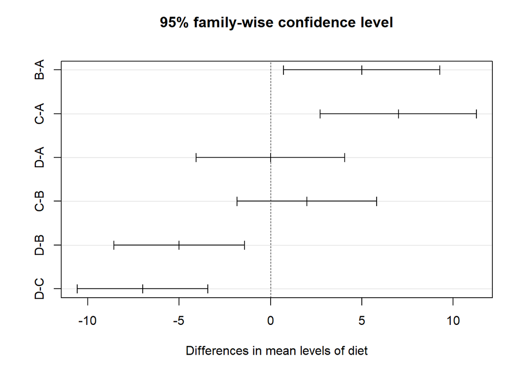

```r
plot(tci)
```

We find that only the A−D and B−C differences are not significant.

# 2 Two factor models

In this chapter, we consider models involving two factors.

## 2.1 Two factors without replication

A general model is:

$$y_{ij} = \mu + \alpha_i + \beta_j + \epsilon_{ij}$$

for $i=1,\ldots,I,~j=1,\ldots,J$. Note that it is not possible to estimate interaction effects.

```r
library(faraway)
data(composite, package="faraway")
composite
```

```
##   strength laser   tape
## 1    25.66   40W   slow
## 2    29.15   50W   slow
## 3    35.73   60W   slow
## 4    28.00   40W medium
## 5    35.09   50W medium
## 6    39.56   60W medium
## 7    20.65   40W   fast
## 8    29.79   50W   fast
## 9    35.66   60W   fast
```

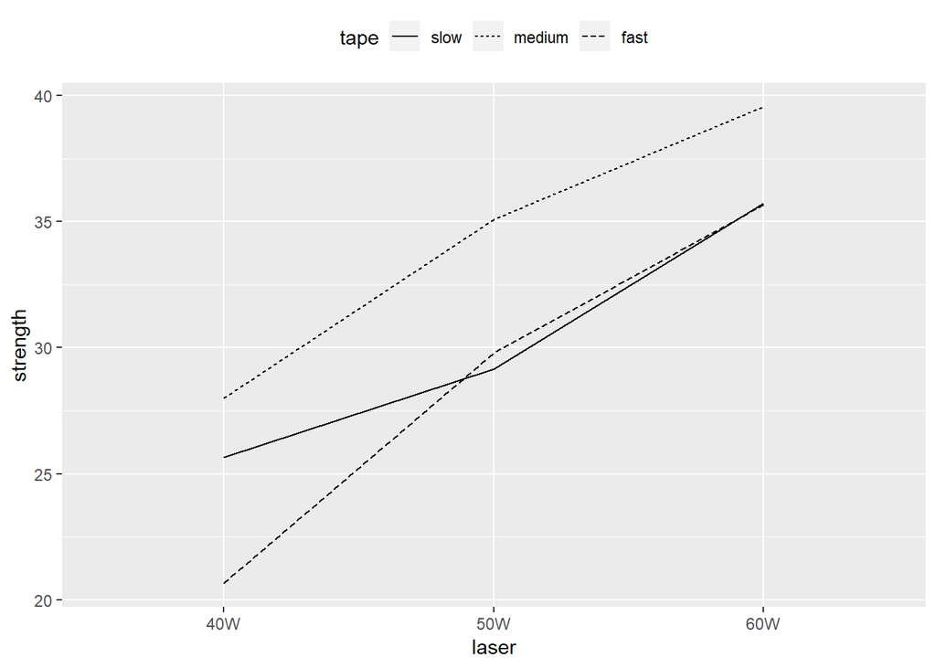

```r
require(ggplot2)
ggplot(composite,aes(x=laser,y=strength,group=tape,linetype=tape))+geom_line()+theme(legend.position = "top", legend.direction = "horizontal")
```

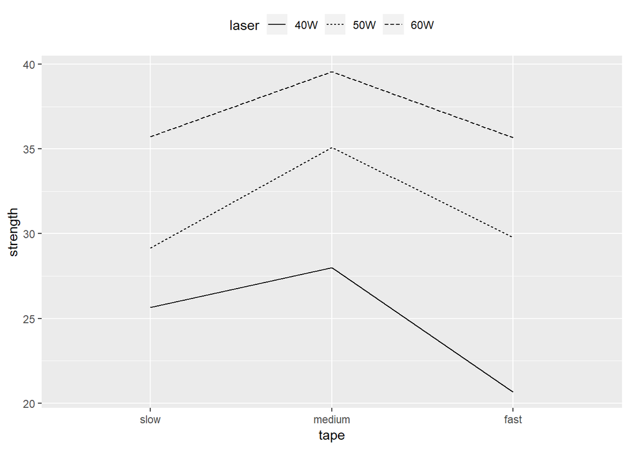

```r
ggplot(composite,aes(x=tape,y=strength,group=laser,linetype=laser))+geom_line()+theme(legend.position = "top", legend.direction = "horizontal")
```

```r
lmod <- lm(strength ~ laser + tape, composite)
coef(lmod)
```

```
## (Intercept)    laser50W    laser60W  tapemedium    tapefast
##   23.917778    6.573333   12.213333    4.036667   -1.480000
```

```r
summary(lmod)
```

```
##
## Call:
## lm(formula = strength ~ laser + tape, data = composite)
##
## Residuals:
##        1        2        3        4        5        6        7        8
##  1.74222 -1.34111 -0.40111  0.04556  0.56222 -0.60778 -1.78778  0.77889
##        9
##  1.00889
##
## Coefficients:
##             Estimate Std. Error t value Pr(>|t|)
## (Intercept)   23.918      1.208  19.803 3.84e-05 ***
## laser50W       6.573      1.323   4.968 0.007661 **
## laser60W      12.213      1.323   9.231 0.000765 ***
## tapemedium     4.037      1.323   3.051 0.037991 *
## tapefast      -1.480      1.323  -1.119 0.325944
## ---
## Signif. codes:  0 '***' 0.001 '**' 0.01 '*' 0.05 '.' 0.1 ' ' 1
##
## Residual standard error: 1.62 on 4 degrees of freedom
## Multiple R-squared:  0.963,  Adjusted R-squared:  0.9259
## F-statistic:    26 on 4 and 4 DF,  p-value: 0.004013
```

```r
anova(lmod)
```

```
## Analysis of Variance Table
##
## Response: strength
##           Df  Sum Sq Mean Sq F value   Pr(>F)
## laser      2 224.184 112.092 42.6893 0.002003 **
## tape       2  48.919  24.459  9.3151 0.031242 *
## Residuals  4  10.503   2.626
## ---
## Signif. codes:  0 '***' 0.001 '**' 0.01 '*' 0.05 '.' 0.1 ' ' 1
```

We see that both factors are significant.

## 2.2 Two factors with replication

A general model is:

$$y_{ijk} = \mu + \alpha_i + \beta_j + (\alpha\beta)_{ij} + \epsilon_{ijk}$$

The interaction effect is tested by fitting a model without theinteraction term and computing the usual F-test. If the interaction effect is found to be significant, we do not test the main effects even if they appear not to be significant.

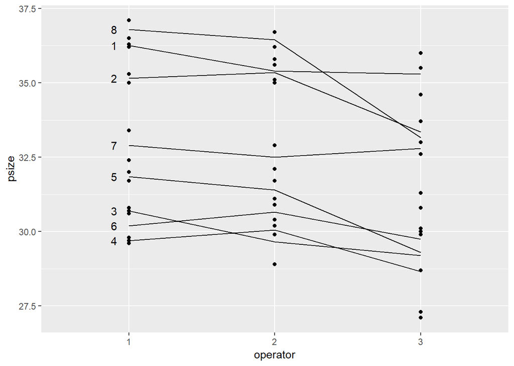

```r
data(pvc, package="faraway")
require(ggplot2)
p <- ggplot(pvc, aes(x=operator,y=psize))+geom_point()+stat_summary(fun.y="mean",geom="line",aes(group=resin))
op1means <- with(pvc[pvc$operator == 1,],sapply(split(psize,resin),mean))
tdf <- data.frame(x=rep(0.9,8),y=op1means,label=1:8)
p + geom_text(data=tdf,aes(x=x,y=y,label=label))
```

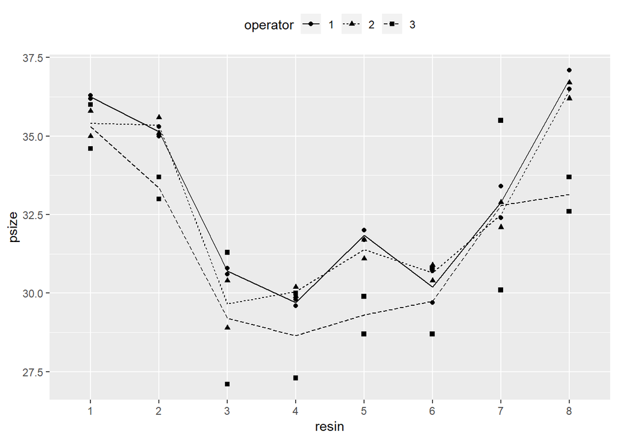

```r
ggplot(pvc, aes(x=resin,y=psize,shape=operator))+geom_point()+stat_summary(fun.y="mean",geom="line",aes(group=operator,linetype=operator))+theme(legend.position = "top", legend.direction = "horizontal")
```

1. Are two factors are significant?
2. Is there an interaction?

```r
lmod <- lm(psize ~ operator*resin, pvc)
lmod1 <- lm(psize ~ operator+resin, pvc)
anova(lmod)
```

```
## Analysis of Variance Table
##
## Response: psize
##                Df  Sum Sq Mean Sq F value    Pr(>F)
## operator        2  20.718  10.359  7.0072   0.00401 **
## resin           7 283.946  40.564 27.4388 5.661e-10 ***
## operator:resin 14  14.335   1.024  0.6926   0.75987
## Residuals      24  35.480   1.478
## ---
## Signif. codes:  0 '***' 0.001 '**' 0.01 '*' 0.05 '.' 0.1 ' ' 1
```

```r
anova(lmod1)
```

```
## Analysis of Variance Table
##
## Response: psize
##           Df  Sum Sq Mean Sq F value    Pr(>F)
## operator   2  20.718  10.359   7.902   0.00135 **
## resin      7 283.946  40.564  30.943 8.111e-14 ***
## Residuals 38  49.815   1.311
## ---
## Signif. codes:  0 '***' 0.001 '**' 0.01 '*' 0.05 '.' 0.1 ' ' 1
```

```r
anova(lmod,lmod1) # test for interaction
```

```
## Analysis of Variance Table
##
## Model 1: psize ~ operator * resin
## Model 2: psize ~ operator + resin
##   Res.Df    RSS  Df Sum of Sq      F Pr(>F)
## 1     24 35.480
## 2     38 49.815 -14   -14.335 0.6926 0.7599
```

Remember that we are doing under normality assumption with equal variances.

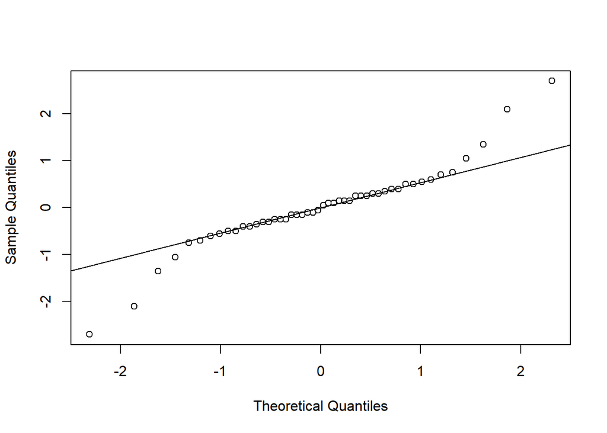

```r
qqnorm(residuals(lmod),main="")
qqline(residuals(lmod))
```

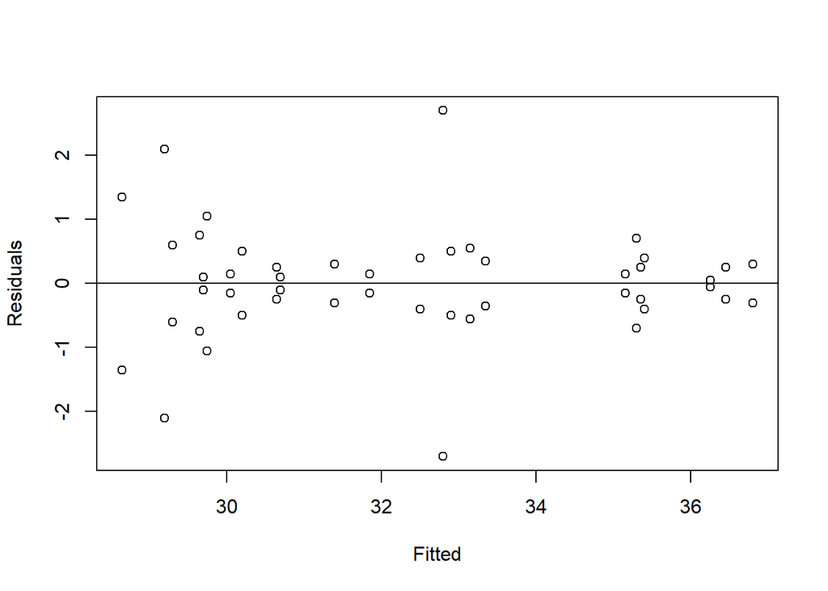

```r
plot(fitted(lmod),residuals(lmod),xlab="Fitted",ylab="Residuals")
abline(h=0)
```

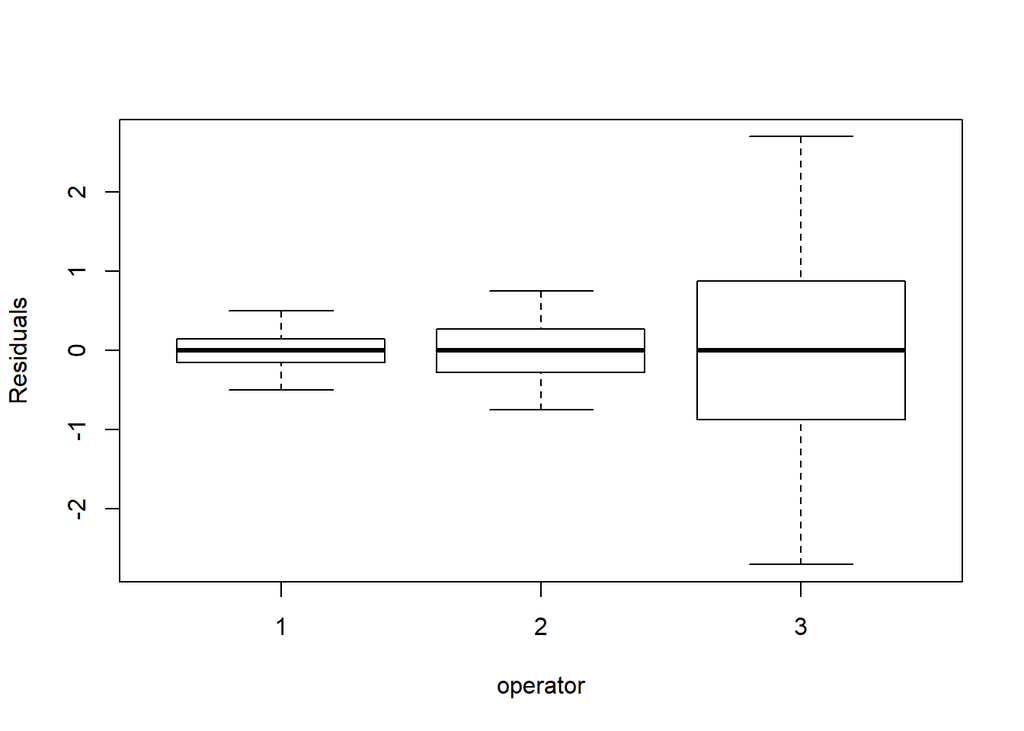

```r
plot(residuals(lmod) ~ operator, pvc, ylab="Residuals")
```

What is violated?

```r
summary(lmod1)
```

```
##
## Call:
## lm(formula = psize ~ operator + resin, data = pvc)
##
## Residuals:
##     Min      1Q  Median      3Q     Max
## -1.9500 -0.6125 -0.0167  0.4063  3.6833
##
## Coefficients:
##             Estimate Std. Error t value Pr(>|t|)
## (Intercept)  36.2396     0.5226  69.345  < 2e-16 ***
## operator2    -0.2625     0.4048  -0.648  0.52059
## operator3    -1.5063     0.4048  -3.721  0.00064 ***
## resin2       -1.0333     0.6610  -1.563  0.12630
## resin3       -5.8000     0.6610  -8.774 1.13e-10 ***
## resin4       -6.1833     0.6610  -9.354 2.11e-11 ***
## resin5       -4.8000     0.6610  -7.261 1.09e-08 ***
## resin6       -5.4500     0.6610  -8.245 5.46e-10 ***
## resin7       -2.9167     0.6610  -4.412 8.16e-05 ***
## resin8       -0.1833     0.6610  -0.277  0.78302
## ---
## Signif. codes:  0 '***' 0.001 '**' 0.01 '*' 0.05 '.' 0.1 ' ' 1
##
## Residual standard error: 1.145 on 38 degrees of freedom
## Multiple R-squared:  0.8595, Adjusted R-squared:  0.8262
## F-statistic: 25.82 on 9 and 38 DF,  p-value: 1.474e-13
```

```r
TukeyHSD(aov(psize ~ operator+resin,data=pvc))
```

```
##   Tukey multiple comparisons of means
##     95% family-wise confidence level
##
## Fit: aov(formula = psize ~ operator + resin, data = pvc)
##
## $operator
##         diff       lwr        upr     p adj
## 2-1 -0.26250 -1.249747  0.7247472 0.7943575
## 3-1 -1.50625 -2.493497 -0.5190028 0.0018126
## 3-2 -1.24375 -2.230997 -0.2565028 0.0106800
##
## $resin
##           diff        lwr        upr     p adj
## 2-1 -1.0333333 -3.1522815  1.0856149 0.7683288
## 3-1 -5.8000000 -7.9189482 -3.6810518 0.0000000
## 4-1 -6.1833333 -8.3022815 -4.0643851 0.0000000
## 5-1 -4.8000000 -6.9189482 -2.6810518 0.0000003
## 6-1 -5.4500000 -7.5689482 -3.3310518 0.0000000
## 7-1 -2.9166667 -5.0356149 -0.7977185 0.0019046
## 8-1 -0.1833333 -2.3022815  1.9356149 0.9999924
## 3-2 -4.7666667 -6.8856149 -2.6477185 0.0000003
## 4-2 -5.1500000 -7.2689482 -3.0310518 0.0000001
## 5-2 -3.7666667 -5.8856149 -1.6477185 0.0000379
## 6-2 -4.4166667 -6.5356149 -2.2977185 0.0000018
## 7-2 -1.8833333 -4.0022815  0.2356149 0.1127668
## 8-2  0.8500000 -1.2689482  2.9689482 0.8984776
## 4-3 -0.3833333 -2.5022815  1.7356149 0.9989372
## 5-3  1.0000000 -1.1189482  3.1189482 0.7958917
## 6-3  0.3500000 -1.7689482  2.4689482 0.9994110
## 7-3  2.8833333  0.7643851  5.0022815 0.0022073
## 8-3  5.6166667  3.4977185  7.7356149 0.0000000
## 5-4  1.3833333 -0.7356149  3.5022815 0.4375901
## 6-4  0.7333333 -1.3856149  2.8522815 0.9507745
## 7-4  3.2666667  1.1477185  5.3856149 0.0003909
## 8-4  6.0000000  3.8810518  8.1189482 0.0000000
## 6-5 -0.6500000 -2.7689482  1.4689482 0.9741405
## 7-5  1.8833333 -0.2356149  4.0022815 0.1127668
## 8-5  4.6166667  2.4977185  6.7356149 0.0000007
## 7-6  2.5333333  0.4143851  4.6522815 0.0098978
## 8-6  5.2666667  3.1477185  7.3856149 0.0000000
## 8-7  2.7333333  0.6143851  4.8522815 0.0042481
```

Which gourps are significantly different?

## 2.3 Another example.

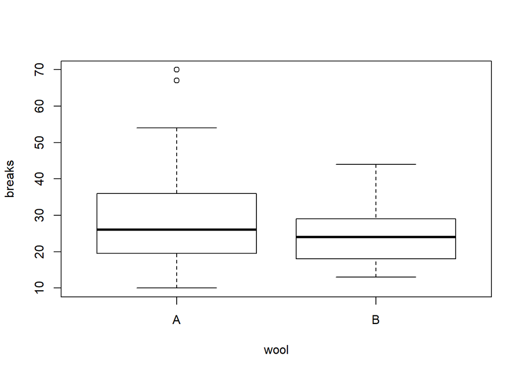

```r
plot(breaks ~ wool, warpbreaks)
```

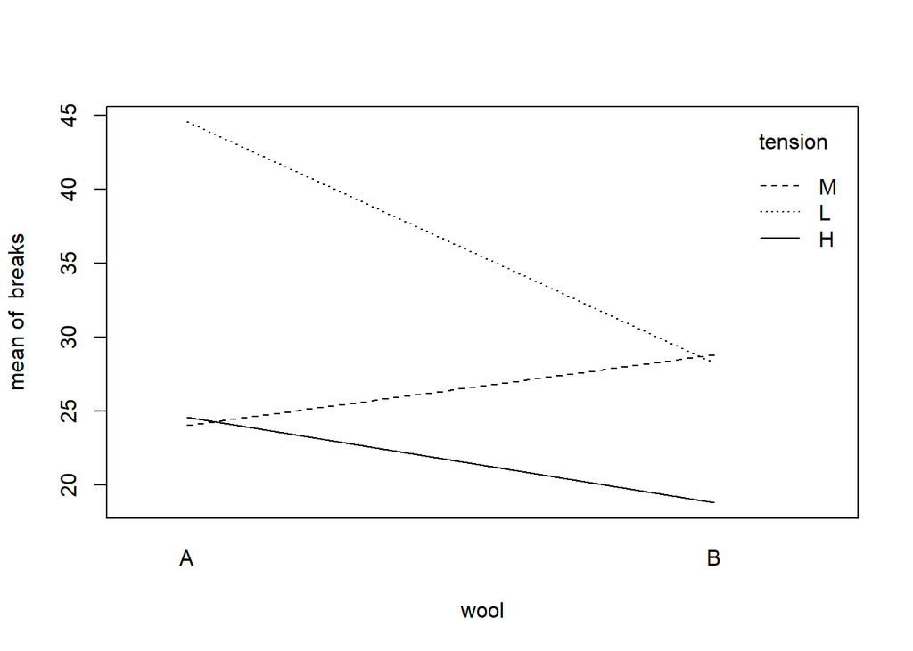

```r
with(warpbreaks,interaction.plot(wool,tension,breaks))
```

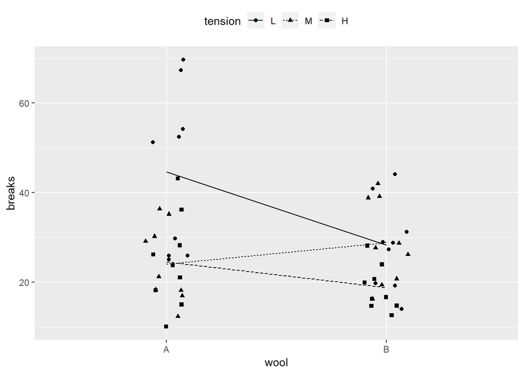

```r
require(ggplot2)
ggplot(warpbreaks, aes(x=wool,y=breaks,shape=tension))+geom_point(position = position_jitter(width = .1))+stat_summary(fun.y="mean",geom="line",aes(group=tension,linetype=tension))+theme(legend.position = "top", legend.direction = "horizontal")
```

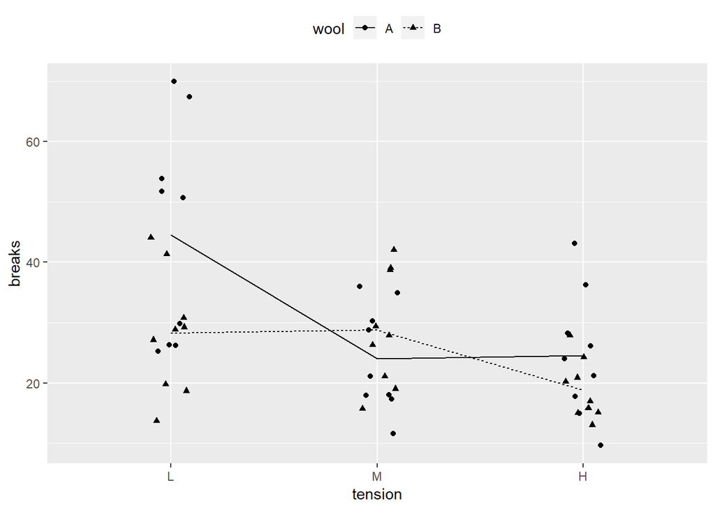

```r
ggplot(warpbreaks, aes(x=tension,y=breaks,shape=wool))+geom_point(position = position_jitter(width = .1))+stat_summary(fun.y="mean",geom="line",aes(group=wool,linetype=wool))+theme(legend.position = "top", legend.direction = "horizontal")
```

Find out if the main and interaction effects are different and compare gourps in means.

# 3 Exercise

1. # 15.4
2. # 16.1